# R Notebook

```r
library(data.table)
library(Rtsne)
library(R.utils)
library(ggplot2)
library(ggcorrplot)
```

# Processing data

## Sade-Feldman(2018) data

```r
fnm1 = "GSE120575_Sade_Feldman_melanoma_single_cells_nolabel_1.txt.gz"
fnm2 = "GSE120575_Sade_Feldman_melanoma_single_cells_2.txt.gz"

sf_tpm1 = fread(paste0("../scRNAseq/Sade_Feldman_2018/", fnm1), fill = TRUE, header = TRUE)

sf_tpm2 = fread(paste0("../scRNAseq/Sade_Feldman_2018/", fnm2), fill = TRUE, drop = 16293, col.names = colnames(sf_tpm1))

ls_tpm = list(sf_tpm1,sf_tpm2)
sf_tpm = rbindlist(ls_tpm)

rm(ls_tpm)
rm(sf_tpm1)
rm(sf_tpm2)
```

```r
dim(sf_tpm) # 55737 x 16292
```

```
## [1] 55737 16292
```

```r
gene.names = sf_tpm$V1
rownames(sf_tpm) = gene.names
sf_tpm$V1 = NULL
```

number of cells that each gene is expressed in, to select genes that have expression in a certain amount of cells

```r
gene.grouping = rep(1:28, each = 2000)[1:dim(sf_tpm)[1]]
cells.per.gene = NULL
for (i in 1:28) {
  temp.counts = rowSums(sf_tpm[gene.grouping==i,] > 0)
  cells.per.gene = c(cells.per.gene,temp.counts)
}
large.express.genes.all = gene.names[which(cells.per.gene > 500)] # kept 12705 genes
rm(gene.grouping)
```

## 11 cell types we defined from Sade-Feldman(2018) data

```r
cell_type = read.table("cell_type.txt",header = TRUE,sep = "\t")
table(cell_type$type)
```

```
##
##               B cells       CD4 T.mem cells       CD4 T.reg cells
##                  1421                  1099                  1313
##           CD8_B cells           CD8_G cells       Dendritic cells
##                  2482                  3043                   275
## Monocytes/Macrophages             NK1 cells             NK2 cells
##                  1341                   463                  1903
##             NK3 cells          Plasma cells           unclustered
##                  1147                   290                  1514
```

```r
clustered_cells = cell_type$cell[cell_type$type != "unclustered"]
# select TPM data for 12705 genes with large expression in 14777 grouped cells
clustered_tpm_LEgenes = sf_tpm[rownames(sf_tpm) %in% large.express.genes.all, ..clustered_cells]
rownames(clustered_tpm_LEgenes) = large.express.genes.all
rm(sf_tpm)
```

## percentages of zero expression genes for each cell in each cell type

```r
# calculate the percentages of genes with zero expression for each cell
zeros.per.cell = colSums(clustered_tpm_LEgenes==0) / nrow(clustered_tpm_LEgenes)
zero.percentages = data.frame(percentage.of.zero = zeros.per.cell, grouping = factor(cell_type$type[match(clustered_cells, cell_type$cell)]))
head(zero.percentages)
```

|  | percentage.of.zero | grouping |
| --- | --- | --- |
| A10_P3_M11 | 0.8492719 | NK2 cells |
| A11_P1_M11 | 0.8802046 | NK2 cells |
| A11_P3_M11 | 0.8794963 | NK2 cells |
| A11_P4_M11 | 0.7811098 | CD4 T.reg cells |
| A12_P3_M11 | 0.9094845 | NK2 cells |
| A12_P6_M11 | 0.7946478 | NK3 cells |

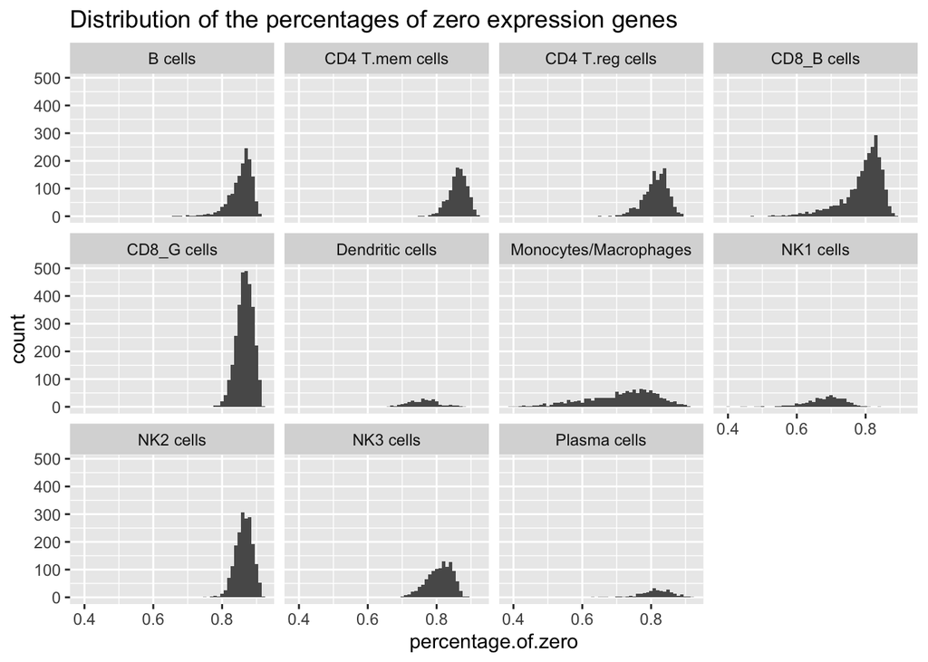

```r
# distribution of the percentages of zero expression genes for cells by cell type
ggplot(data = zero.percentages) +
  geom_histogram(aes(x=percentage.of.zero), binwidth = 0.01) +
  facet_wrap(~grouping) +
  ggtitle("Distribution of the percentages of zero expression genes")
```

```r
rm(zeros.per.cell)
```

Based on the graph, the spread of distribution of the percentages of zero expression genes is quite different for each cell type, so I didn’t use a single number as the cutoff to choose which cells to keep, instead, I select 100 cells with the smallest percentages of zero expression genes.

```r
fewzero_cells = unname(unlist(by(zero.percentages, zero.percentages$grouping, FUN = function(x) rownames(x)[order(x$percentage.of.zero)][1:100])))
```

## LM22 signature matrix

- select genes that appear both in the LM22 signature matrix and the SF data
- in those genes, further select genes that have expression in a relatively large amount of cells

```r
CBST_LM22 = read.table("../_reference/LM22.txt", sep = "\t", header = TRUE, as.is = TRUE)
head(CBST_LM22)
```

|  | Gene.symbol | B.cells.naive | B.cells.memory | Plasma.cells | T.cells.CD8 | T.cells.CD4.naive | T.cells.CD4.memory.resting | T.cells.CD4.memory.activated | T.cells.follicular.helper | T.cells.regulatory..Tregs. | T.cells.gamma.delta | NK.cells.resting | NK.cells.activated | Monocytes | Macrophages.M0 | Macrophages.M1 | Macrophages.M2 | Dendritic.cells.resting | Dendritic.cells.activated | Mast.cells.resting | Mast.cells.activated | Eosinophils | Neutrophils |
| --- | --- | --- | --- | --- | --- | --- | --- | --- | --- | --- | --- | --- | --- | --- | --- | --- | --- | --- | --- | --- | --- | --- | --- |
| 1 | ABCB4 | 555.71345 | 10.74423 | 7.225819 | 4.31128 | 4.60586 | 7.406442 | 8.043976 | 6.469993 | 7.833082 | 9.312295 | 13.68284 | 4.556713 | 6.202496 | 7.95136 | 27.55771 | 121.43228 | 114.63675 | 4.872184 | 4.727985 | 34.11366 | 15.03053 | 14.90689 |
| 2 | ABCB9 | 15.60354 | 22.09479 | 653.392328 | 24.22372 | 35.67151 | 30.048192 | 38.455423 | 17.604795 | 46.073657 | 19.715722 | 21.86372 | 16.396143 | 20.309426 | 56.25189 | 29.38088 | 40.39026 | 123.99331 | 23.384603 | 53.466757 | 23.61575 | 29.78644 | 33.67915 |
| 3 | ACAP1 | 215.30595 | 321.62102 | 38.616872 | 1055.61338 | 1790.09717 | 922.152747 | 340.883424 | 1107.798265 | 1995.482601 | 280.075719 | 512.63691 | 387.581742 | 190.879024 | 48.97222 | 30.97425 | 23.05515 | 61.38655 | 26.412923 | 104.200198 | 73.60793 | 696.44280 | 596.02596 |
| 4 | ACHE | 15.11795 | 16.64885 | 22.123737 | 13.42829 | 27.18773 | 18.444927 | 13.441268 | 14.805542 | 24.652712 | 33.658448 | 16.65374 | 13.441268 | 16.375268 | 13.69296 | 1373.06962 | 48.58576 | 16.71547 | 193.159977 | 13.948778 | 20.50125 | 40.41493 | 22.76649 |
| 5 | ACP5 | 605.89738 | 1935.20148 | 1120.104684 | 306.31252 | 744.65660 | 557.819820 | 248.546932 | 711.949744 | 958.916018 | 493.969120 | 340.82014 | 239.277068 | 512.931382 | 13644.17230 | 1062.47591 | 7633.96018 | 13825.05363 | 3989.865169 | 263.497930 | 323.38128 | 860.56337 | 307.14280 |
| 6 | ADAM28 | 1943.74270 | 1148.12014 | 324.780800 | 22.68972 | 40.06171 | 21.233311 | 15.209620 | 24.281406 | 74.766335 | 24.370752 | 193.60939 | 94.405818 | 58.311203 | 54.96649 | 274.64000 | 360.68204 | 37.29173 | 53.219649 | 137.853628 | 116.87950 | 546.00616 | 128.68607 |

```r
CBST.SFgenes = CBST_LM22$Gene.symbol[CBST_LM22$Gene.symbol%in%gene.names] # 538 out of 547
CBST.largeExpression.genes = CBST.SFgenes[CBST.SFgenes %in% large.express.genes.all] # 323 out of 538
CBST_SFLEgenes_LM22 = CBST_LM22[CBST_LM22$Gene.symbol%in%CBST.largeExpression.genes,] # 323 x 23
head(CBST_SFLEgenes_LM22)
```

|  | Gene.symbol | B.cells.naive | B.cells.memory | Plasma.cells | T.cells.CD8 | T.cells.CD4.naive | T.cells.CD4.memory.resting | T.cells.CD4.memory.activated | T.cells.follicular.helper | T.cells.regulatory..Tregs. | T.cells.gamma.delta | NK.cells.resting | NK.cells.activated | Monocytes | Macrophages.M0 | Macrophages.M1 | Macrophages.M2 | Dendritic.cells.resting | Dendritic.cells.activated | Mast.cells.resting | Mast.cells.activated | Eosinophils | Neutrophils |
| --- | --- | --- | --- | --- | --- | --- | --- | --- | --- | --- | --- | --- | --- | --- | --- | --- | --- | --- | --- | --- | --- | --- | --- |
| 3 | ACAP1 | 215.3060 | 321.62102 | 38.61687 | 1055.61338 | 1790.09717 | 922.15275 | 340.88342 | 1107.79826 | 1995.48260 | 280.07572 | 512.63691 | 387.58174 | 190.8790 | 48.97222 | 30.97425 | 23.05515 | 61.38655 | 26.41292 | 104.20020 | 73.60793 | 696.44280 | 596.0260 |
| 5 | ACP5 | 605.8974 | 1935.20148 | 1120.10468 | 306.31252 | 744.65660 | 557.81982 | 248.54693 | 711.94974 | 958.91602 | 493.96912 | 340.82014 | 239.27707 | 512.9314 | 13644.17230 | 1062.47591 | 7633.96018 | 13825.05363 | 3989.86517 | 263.49793 | 323.38128 | 860.56337 | 307.1428 |
| 6 | ADAM28 | 1943.7427 | 1148.12014 | 324.78080 | 22.68972 | 40.06171 | 21.23331 | 15.20962 | 24.28141 | 74.76634 | 24.37075 | 193.60939 | 94.40582 | 58.3112 | 54.96649 | 274.64000 | 360.68204 | 37.29173 | 53.21965 | 137.85363 | 116.87950 | 546.00616 | 128.6861 |
| 9 | ADRB2 | 486.3438 | 510.08134 | 289.79845 | 899.64850 | 77.15395 | 595.21055 | 142.83191 | 97.17423 | 217.06277 | 2378.45213 | 1957.53925 | 2360.47130 | 664.8840 | 143.01788 | 787.62397 | 363.18501 | 175.63347 | 82.91166 | 4628.68158 | 2887.87424 | 1969.02882 | 735.6635 |
| 10 | AIF1 | 24.0743 | 20.32186 | 21.96957 | 742.81582 | 718.61479 | 35.17225 | 39.50876 | 19.07768 | 29.36704 | 1086.95966 | 105.73455 | 23.17043 | 8655.6800 | 1841.26951 | 1611.22857 | 11610.29035 | 3285.64082 | 26.92386 | 1851.12413 | 1672.63033 | 51.17646 | 6260.6405 |
| 11 | AIM2 | 327.9581 | 4538.99105 | 1429.67409 | 294.48461 | 57.08080 | 250.29958 | 3311.97839 | 1115.68161 | 315.64587 | 407.59290 | 87.22742 | 134.49587 | 536.1119 | 181.95710 | 2965.88816 | 148.28452 | 176.96159 | 907.03996 | 93.47145 | 62.12545 | 117.50771 | 794.2146 |

# Compare the correlation of cell types

- Compare the correlation between our 11 cell types.
- Compare the correlation between the cell types in the LM22 vs. the 11 cell types we had.
- Two types of correlation: using all cells for each cell type to calculate mean gene expression, or calculate the mean expression using 100 cells with smallest percentages of zero expression genes.

## Correlations between our 11 cell types

### using mean expression of large expression genes shared between SF data and LM22 matrix

```r
LEgenes_CBST_tpm = as.data.table(t(clustered_tpm_LEgenes[large.express.genes.all %in% CBST.largeExpression.genes,]))
rownames(LEgenes_CBST_tpm) = clustered_cells
colnames(LEgenes_CBST_tpm) = CBST.largeExpression.genes
LEgenes_CBST_tpm[1:5,1:5]
```

| ACAP1 | ACP5 | ADAM28 | ADRB2 | AIF1 |
| --- | --- | --- | --- | --- |
| 0 | 0.00 | 0.00 | 0 | 0 |
| 0 | 0.00 | 0.00 | 0 | 0 |
| 0 | 0.00 | 0.00 | 0 | 0 |
| 0 | 5.01 | 8.84 | 0 | 0 |
| 0 | 0.00 | 0.00 | 0 | 0 |

```r
LEgenes_CBST_tpm$grouping = factor(cell_type$type[match(row.names(LEgenes_CBST_tpm), cell_type$cell)])
table(LEgenes_CBST_tpm$grouping)
```

```
##
##               B cells       CD4 T.mem cells       CD4 T.reg cells
##                  1421                  1099                  1313
##           CD8_B cells           CD8_G cells       Dendritic cells
##                  2482                  3043                   275
## Monocytes/Macrophages             NK1 cells             NK2 cells
##                  1341                   463                  1903
##             NK3 cells          Plasma cells
##                  1147                   290
```

```r
LEgene_CBST_expression = LEgenes_CBST_tpm[, lapply(.SD, mean), by = grouping] # 11 x 324
LEgene_CBST_expression = LEgene_CBST_expression[order(LEgene_CBST_expression$grouping),]
LEgene_CBST_expression[,1:6]
```

| grouping | ACAP1 | ACP5 | ADAM28 | ADRB2 | AIF1 |
| --- | --- | --- | --- | --- | --- |
| B cells | 0.02612949 | 1.0348839 | 7.51723434 | 0.02662913 | 0.02637579 |
| CD4 T.mem cells | 0.53636033 | 0.5984076 | 0.78303913 | 0.20624204 | 0.26951774 |
| CD4 T.reg cells | 2.32328256 | 2.1872277 | 2.12461538 | 0.13843869 | 0.46322163 |
| CD8_B cells | 0.27127317 | 4.8322361 | 0.97019742 | 0.20377921 | 0.80847301 |
| CD8_G cells | 0.07474532 | 0.9484555 | 0.27997042 | 0.19440026 | 0.46878409 |
| Dendritic cells | 0.03563636 | 3.4953818 | 0.04643636 | 0.19840000 | 0.11600000 |
| Monocytes/Macrophages | 0.73495899 | 1.9523714 | 0.34462342 | 0.15850858 | 0.26099925 |
| NK1 cells | 1.08051836 | 5.5719222 | 2.11488121 | 0.14524838 | 0.28913607 |
| NK2 cells | 0.16889122 | 1.5455859 | 0.52730426 | 0.27441934 | 0.44117183 |
| NK3 cells | 0.43845684 | 4.4630340 | 0.98962511 | 0.24500436 | 0.70850915 |

[output cut: 1 more lines]

```r
LEgene_CBST_compare_expression = as.data.frame(t(LEgene_CBST_expression[,-1]))
colnames(LEgene_CBST_compare_expression) = LEgene_CBST_expression$grouping
head(LEgene_CBST_compare_expression)
```

|  | B cells | CD4 T.mem cells | CD4 T.reg cells | CD8_B cells | CD8_G cells | Dendritic cells | Monocytes/Macrophages | NK1 cells | NK2 cells | NK3 cells | Plasma cells |
| --- | --- | --- | --- | --- | --- | --- | --- | --- | --- | --- | --- |
| ACAP1 | 0.02612949 | 0.5363603 | 2.3232826 | 0.27127317 | 0.07474532 | 0.03563636 | 0.7349590 | 1.0805184 | 0.1688912 | 0.4384568 | 0.02131034 |
| ACP5 | 1.03488388 | 0.5984076 | 2.1872277 | 4.83223610 | 0.94845547 | 3.49538182 | 1.9523714 | 5.5719222 | 1.5455859 | 4.4630340 | 5.45458621 |
| ADAM28 | 7.51723434 | 0.7830391 | 2.1246154 | 0.97019742 | 0.27997042 | 0.04643636 | 0.3446234 | 2.1148812 | 0.5273043 | 0.9896251 | 3.03472414 |
| ADRB2 | 0.02662913 | 0.2062420 | 0.1384387 | 0.20377921 | 0.19440026 | 0.19840000 | 0.1585086 | 0.1452484 | 0.2744193 | 0.2450044 | 0.01531034 |
| AIF1 | 0.02637579 | 0.2695177 | 0.4632216 | 0.80847301 | 0.46878409 | 0.11600000 | 0.2609993 | 0.2891361 | 0.4411718 | 0.7085092 | 0.57403448 |
| AIM2 | 0.05843772 | 4.1224750 | 6.9611120 | 0.02251813 | 0.07971738 | 8.67472727 | 6.3213348 | 3.5315335 | 2.1717709 | 2.0140366 | 0.01617241 |

```r
rm(LEgene_CBST_expression)
rm(LEgenes_CBST_tpm)
```

The patterns of the correlation roughly match our expectation: - Plasma cells, Monocytes/Macrophages, Dendritic cells and B cells do no have major correlation with other cell types, matches the clustering result that these 4 cell types form most distinct clusters - The 3 NK cell clusters are closely related with each other - CD8 cells, NK cells, and CD4 T cells are closely related

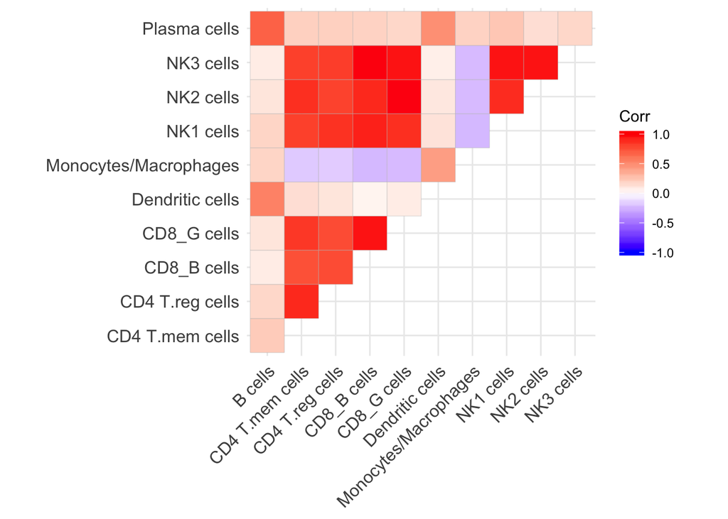

```r
cormat_LE.CBSTgenes_11type = cor(LEgene_CBST_compare_expression, method = "spearman")
ggcorrplot(cormat_LE.CBSTgenes_11type,type = "upper")
```

### using mean expression for large expression genes shared between SF data and LM22 matrix over cells with fewer zero gene expression

```r
LEgenes_CBST_few0_tpm = as.data.table(t(clustered_tpm_LEgenes[large.express.genes.all %in% CBST.largeExpression.genes, ..fewzero_cells]))
rownames(LEgenes_CBST_few0_tpm) = fewzero_cells
colnames(LEgenes_CBST_few0_tpm) = CBST.largeExpression.genes
LEgenes_CBST_few0_tpm[1:5,1:5]
```

| ACAP1 | ACP5 | ADAM28 | ADRB2 | AIF1 |
| --- | --- | --- | --- | --- |
| 7.76 | 6.26 | 8.35 | 0.00 | 0 |
| 0.00 | 8.52 | 11.00 | 0.00 | 0 |
| 0.00 | 7.71 | 11.36 | 0.66 | 0 |
| 0.00 | 7.07 | 7.40 | 0.00 | 0 |
| 0.00 | 1.43 | 10.11 | 0.00 | 0 |

```r
LEgenes_CBST_few0_tpm$grouping = factor(cell_type$type[match(row.names(LEgenes_CBST_few0_tpm), cell_type$cell)])
table(LEgenes_CBST_few0_tpm$grouping)
```

```
##
##               B cells       CD4 T.mem cells       CD4 T.reg cells
##                   100                   100                   100
##           CD8_B cells           CD8_G cells       Dendritic cells
##                   100                   100                   100
## Monocytes/Macrophages             NK1 cells             NK2 cells
##                   100                   100                   100
##             NK3 cells          Plasma cells
##                   100                   100
```

```r
LEgene_CBST_few0_expression = LEgenes_CBST_few0_tpm[, lapply(.SD, mean), by = grouping] # 11 x 324
LEgene_CBST_few0_expression[,1:6]
```

| grouping | ACAP1 | ACP5 | ADAM28 | ADRB2 | AIF1 |
| --- | --- | --- | --- | --- | --- |
| B cells | 0.1726 | 2.5379 | 9.3839 | 0.0606 | 0.0427 |
| CD4 T.mem cells | 0.2694 | 0.6313 | 1.2052 | 0.2082 | 0.2340 |
| CD4 T.reg cells | 3.1859 | 3.5622 | 2.5785 | 0.2111 | 0.5102 |
| CD8_B cells | 0.7156 | 5.7225 | 1.7148 | 0.1879 | 0.3756 |
| CD8_G cells | 0.0000 | 0.5235 | 0.1751 | 0.1472 | 0.4217 |
| Dendritic cells | 0.0290 | 4.6113 | 0.0831 | 0.2947 | 0.1650 |
| Monocytes/Macrophages | 2.5100 | 1.8603 | 0.2862 | 0.1251 | 0.0333 |
| NK1 cells | 1.4674 | 5.6412 | 2.3207 | 0.1509 | 0.1088 |
| NK2 cells | 0.1774 | 1.6261 | 1.0816 | 0.2185 | 0.2127 |
| NK3 cells | 0.8544 | 5.8316 | 2.1186 | 0.2509 | 1.2184 |

[output cut: 1 more lines]

```r
LEgene_CBST_few0_compare_expression = as.data.frame(t(LEgene_CBST_few0_expression[,-1]))
colnames(LEgene_CBST_few0_compare_expression) = LEgene_CBST_few0_expression$grouping
head(LEgene_CBST_few0_compare_expression)
```

|  | B cells | CD4 T.mem cells | CD4 T.reg cells | CD8_B cells | CD8_G cells | Dendritic cells | Monocytes/Macrophages | NK1 cells | NK2 cells | NK3 cells | Plasma cells |
| --- | --- | --- | --- | --- | --- | --- | --- | --- | --- | --- | --- |
| ACAP1 | 0.1726 | 0.2694 | 3.1859 | 0.7156 | 0.0000 | 0.0290 | 2.5100 | 1.4674 | 0.1774 | 0.8544 | 0.0000 |
| ACP5 | 2.5379 | 0.6313 | 3.5622 | 5.7225 | 0.5235 | 4.6113 | 1.8603 | 5.6412 | 1.6261 | 5.8316 | 6.2608 |
| ADAM28 | 9.3839 | 1.2052 | 2.5785 | 1.7148 | 0.1751 | 0.0831 | 0.2862 | 2.3207 | 1.0816 | 2.1186 | 3.8325 |
| ADRB2 | 0.0606 | 0.2082 | 0.2111 | 0.1879 | 0.1472 | 0.2947 | 0.1251 | 0.1509 | 0.2185 | 0.2509 | 0.0391 |
| AIF1 | 0.0427 | 0.2340 | 0.5102 | 0.3756 | 0.4217 | 0.1650 | 0.0333 | 0.1088 | 0.2127 | 1.2184 | 0.7229 |
| AIM2 | 0.4044 | 4.5222 | 7.1091 | 0.0173 | 0.0453 | 8.9776 | 7.8268 | 3.2826 | 2.2834 | 2.2697 | 0.0334 |

```r
rm(LEgene_CBST_few0_expression)
rm(LEgenes_CBST_few0_tpm)
```

The result using cells with fewer zero expression genes is not very different from the result using all cells.

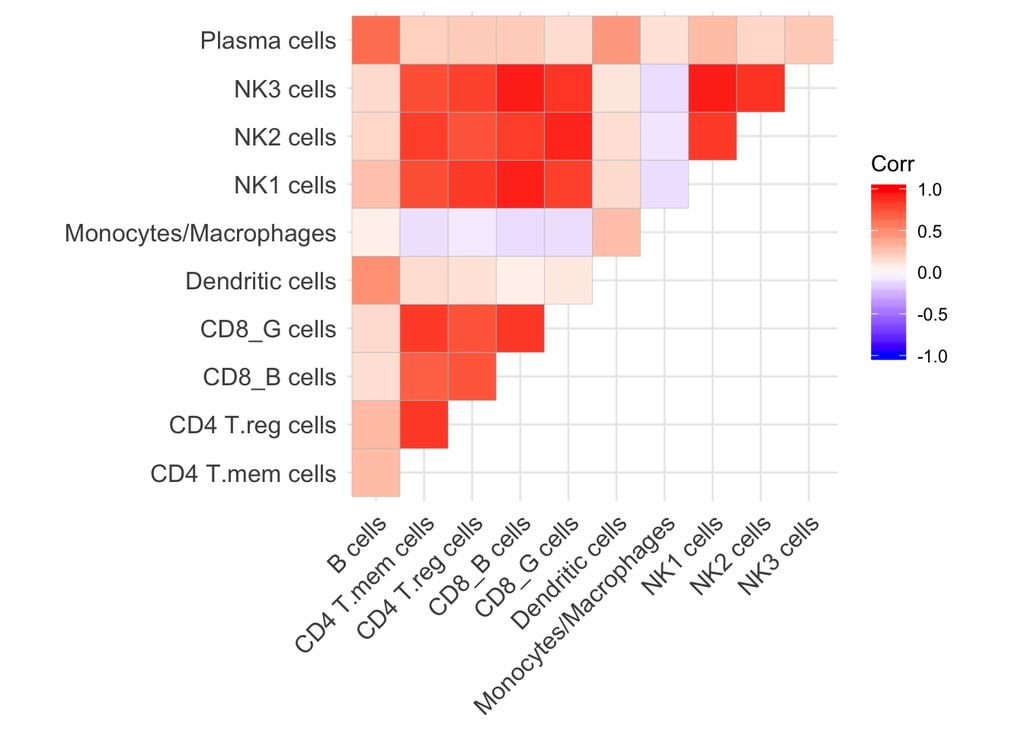

```r
cormat_LE.CBST.few0genes_11type = cor(LEgene_CBST_few0_compare_expression, method = "spearman")
ggcorrplot(cormat_LE.CBST.few0genes_11type,type = "upper")
```

## Correlations between our 11 cell types and the cell types in the LM22 matrix

### using mean expression of large expression genes shared between SF data and LM22 matrix

```r
cormat_LM22_11type = matrix(0,nrow = 22, ncol = 11)
colnames(cormat_LM22_11type)= colnames(LEgene_CBST_compare_expression)
rownames(cormat_LM22_11type) = colnames(CBST_SFLEgenes_LM22)[-1]
for (i in 1:22) {
  for (j in 1:11) {
   cormat_LM22_11type[i,j] = cor(as.numeric(LEgene_CBST_compare_expression[,j]), as.numeric(CBST_SFLEgenes_LM22[,i+1]),method = "spearman")
  }
}
```

The correlations between our 11 cell types and the cell types in the LM22 matrix still have some unexpected patterns

[figure not shown]

```r
ggcorrplot(t(cormat_LM22_11type))
```

### using mean expression for large expression genes shared between SF data and LM22 matrix over cells with fewer zero gene expression

```r
cormat_LM22_11type_few0 = matrix(0,nrow = 22, ncol = 11)
colnames(cormat_LM22_11type_few0)= colnames(LEgene_CBST_few0_compare_expression)
rownames(cormat_LM22_11type_few0) = colnames(CBST_SFLEgenes_LM22)[-1]
for (i in 1:22) {
  for (j in 1:11) {
   cormat_LM22_11type_few0[i,j] = cor(as.numeric(LEgene_CBST_few0_compare_expression[,j]), as.numeric(CBST_SFLEgenes_LM22[,i+1]),method = "spearman")
  }
}
```

The result using cells with fewer zero expression genes is not very different from the result using all cells.

[figure not shown]

```r
ggcorrplot(t(cormat_LM22_11type_few0))
```